# Team Question Set

Kobe Pranivong; Yi Hang Khor

2/5/2020

1. What is the overall number of chocolate bars rated?

```r
choco <- read.csv("https://xdaiisu.github.io/ds202materials/hwlabs/choco.csv")
dim(choco)[1]
```

```
## [1] 1852
```

The overall number of chocolate bars rated is 1852.

2. How does the number of ratings depend upon the year?

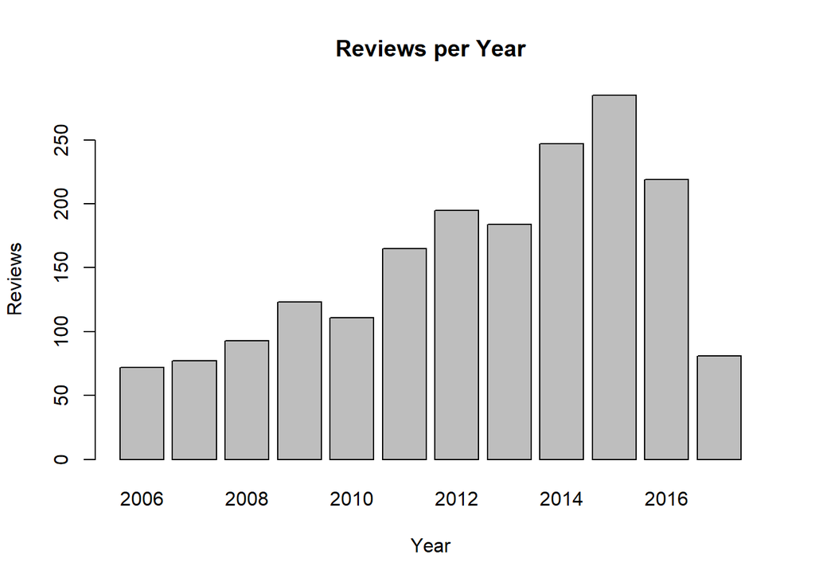

```r
c <- table(choco$Review.Date)
barplot(c, main="Reviews per Year", xlab="Year", ylab="Reviews")
```

There was a trend of increasing number of reviews from 2006-2015, following a sharp decline in 2017.

3. Which are the three locations with the most ratings? How do ratings compare across these company locations?

```r
t = table(choco$Company.Location)
order(t, decreasing = TRUE)
```

```
##  [1] 58 19  8 57 30 15  3  5 55 20  4 51 10 25 59  7 31 33 37 40 13 60 23 47  2
## [26] 11 29 42  1 24 32 14 39 50 54 17 28 35 36 44 46 56 22 26 43 45 48 49  6  9
## [51] 18 27 52 12 16 21 34 38 41 53 61
```

```r
first = t[58]
first
```

```
## U.S.A.
##    787
```

```r
second = t[19]
second
```

```
## France
##    158
```

```r
third = t[8]
third
```

```
## Canada
##    132
```

The three locations with the most ratings are: U.S.A., France, and Canada. France ratings have the lowest range of the three. France also has the most outliers. USA and Canada have very similar ranges, but Canada’s IQR range is higher than USA’s.

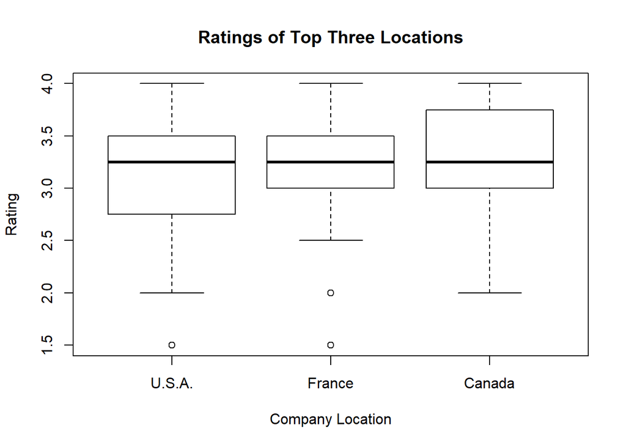

```r
df = choco[choco$Company.Location == "U.S.A." | choco$Company.Location == "France" | choco$Company.Location == "Canada", ]
df$Company.Location = factor(df$Company.Location, levels=c("U.S.A.", "France", "Canada"))
boxplot(df$Rating ~ df$Company.Location, main = "Ratings of Top Three Locations", xlab = "Company Location", ylab = "Rating")
```

4. Brainstorm and write down an interesting question that can be answer from the dataset. The question should not duplicate the questions above.

What are the top companies in the top company location (USA)? How about Canada?

5. Answer the question from the dataset.

```r
usa.data = choco[(choco$Company.Location == "U.S.A."), ]
(highest.levels = levels(reorder(usa.data$Company, usa.data$Rating))[1:10])
```

```
##  [1] "Jacque Torres"              "Love Bar"
##  [3] "Shark's"                    "Marsatta"
##  [5] "Cacao Atlanta"              "Chocolate Alchemist-Philly"
##  [7] "Chocovivo"                  "Garden Island"
##  [9] "Lake Champlain (Callebaut)" "Oakland Chocolate Co."
```

```r
canada.data = choco[(choco$Company.Location == "Canada"), ]
(secondhighest.levels = levels(reorder(canada.data$Company, canada.data$Rating))[1:10])
```

```
##  [1] "Chocolats Privilege" "Desbarres"           "Olivia"
##  [4] "Chaleur B"           "Choklat"             "organicfair"
##  [7] "Habitual"            "Uncouth"             "Palette de Bine"
## [10] "Ambrosia"
```

6. Write one paragraph commenting on the workflow.

We did the first three questions on Kobe’s computer, and then we pushed it onto the git repository. Bobby then pulled it and we did the last three questions on Bobby’s computer. We worked on the code and questions together throughout all 6 questions. After we completed everything, Bobby pushed the final product back onto the git repository and Kobe pulled it again so it updated on his computer.